# Notebook

**Wie Modelle lernen - Optimale Koeffizienten finden**

Dr. Matthias Hölzl

## Das Lernproblem

Gegeben:

- Trainingsdaten X (Features)
- Zielwerte y (was wir vorhersagen wollen)

Gesucht:

- Koeffizienten und Intercept
- Die die Fehler minimieren

```python
import numpy as np
import matplotlib.pyplot as plt
from sklearn.linear_model import LinearRegression
```

## Ein einfaches Beispiel

Einfache Trainingsdaten

```python
X_simple = np.array([[1], [2], [3], [4], [5]])
y_simple = np.array([3, 5, 7, 9, 11])
```

Visualisiere

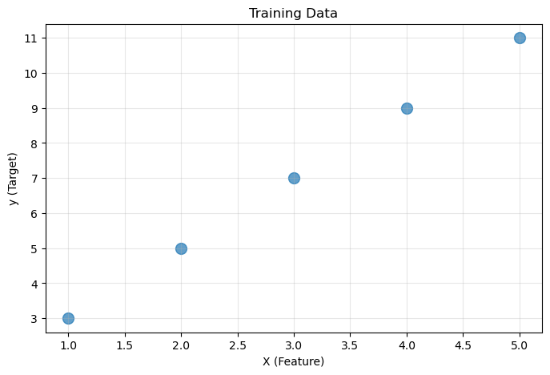

```python
plt.figure(figsize=(8, 5))
plt.scatter(X_simple, y_simple, s=100, alpha=0.7)
plt.xlabel("X (Feature)")
plt.ylabel("y (Target)")
plt.title("Training Data")
plt.grid(True, alpha=0.3)
plt.show()
```

## Was sind "gute" Koeffizienten?

Wir wollen eine Linie, die:

- Möglichst nah an allen Punkten ist
- Die Fehler minimiert
- Gut generalisiert

Probiere verschiedene Koeffizienten

```python
from plot_utils import plot_coefficients_effect
```

```python
coefficients_to_try = [1.5, 2.0, 2.5]
intercepts_to_try = [1.5, 1.0, 0.5]
```

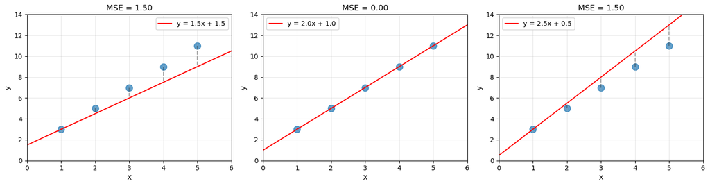

```python
plot_coefficients_effect(X_simple, y_simple, coefficients_to_try, intercepts_to_try)
```

## Die Kosten von Fehlern

**Mean Squared Error (MSE)**:

- Misst durchschnittliche quadratische Abweichung
- Bestraft große Fehler stärker
- MSE = $(1/n) × \sum(y_{\textrm{true}} - y_{\textrm{pred}})²$

## Visualisierung der Fehleroberfläche

Plotte Fehleroberfläche

- 3D-Oberfläche
- Konturplot

```python
from plot_utils import plot_error_surface
```

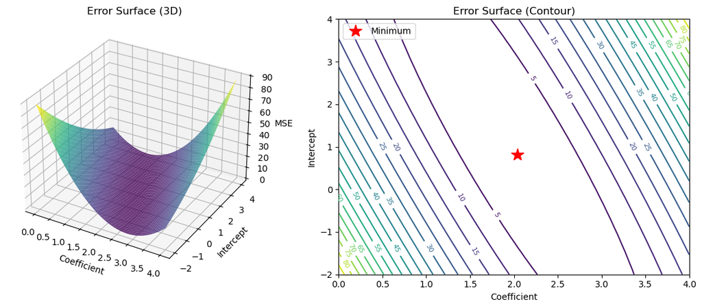

```python
best_coef, best_intercept, min_mse = plot_error_surface(X_simple, y_simple)
```

```python
print(f"Best coefficient: {best_coef:.3f}")
print(f"Best intercept: {best_intercept:.3f}")
print(f"Minimum MSE: {min_mse:.3f}")
```

```
Best coefficient: 2.041
Best intercept: 0.816
Minimum MSE: 0.007
```

## Die mathematische Lösung

Es gibt eine Formel für die optimalen Koeffizienten!

**Normalgleichung** (vereinfacht):

- Koeffizienten = $(X^T × X)^{-1} × X^T × y$
- $X^T$ = Transponierte von $X$
- $M^{-1}$ = Inverse von $M$

## Warum funktioniert das?

- Die Normalgleichung findet das Minimum der Fehleroberfläche
- Mathematisch: Setzt die Ableitung der Kostenfunktion auf 0
- Resultat: Optimale Koeffizienten in einem Schritt!

(Die Herleitung ist komplex, aber die Anwendung ist einfach!)

## Schritt 1: Daten vorbereiten

Für den Intercept fügen wir eine Spalte mit Einsen hinzu:

```python
X_simple
```

```
array([[1],
       [2],
       [3],
       [4],
       [5]])
```

```python
X_with_intercept = np.column_stack([np.ones(len(X_simple)), X_simple])
```

```python
X_with_intercept
```

```
array([[1., 1.],
       [1., 2.],
       [1., 3.],
       [1., 4.],
       [1., 5.]])
```

## Schritt 2: Normalgleichung anwenden

Normalgleichung: $θ = (X^T X)^{-1} X^T y$

```python
X = X_with_intercept
```

```python
X_transpose = X.T
```

```python
X_transpose
```

```
array([[1., 1., 1., 1., 1.],
       [1., 2., 3., 4., 5.]])
```

Berechne $X^T × X$

```python
XtX = X_transpose @ X
```

```python
XtX
```

```
array([[ 5., 15.],
       [15., 55.]])
```

Berechne Inverse

```python
XtX_inv = np.linalg.inv(XtX)
```

```python
XtX_inv
```

```
array([[ 1.1, -0.3],
       [-0.3,  0.1]])
```

```python
XtX_inv @ XtX
```

```
array([[1., 0.],
       [0., 1.]])
```

```python
XtX @ XtX_inv
```

```
array([[1., 0.],
       [0., 1.]])
```

Berechne X^T × y

```python
Xty = X_transpose @ y_simple
```

```python
Xty
```

```
array([ 35., 125.])
```

Finale Berechnung: $θ = (X^T × X)^{-1} × X^T × y$

```python
theta = XtX_inv @ Xty
```

Optimale Parameter:

- Intercept (Y-Abschnitt): $\theta[0]$
- Koeffizient: $\theta[1]$

```python
theta[0]
```

```
np.float64(1.000000000000007)
```

```python
theta[1]
```

```
np.float64(2.0)
```

## Vergleich mit Scikit-Learn

Trainiere Scikit-Learn-Modell

```python
sklearn_model = LinearRegression()
sklearn_model.fit(X_simple, y_simple)
```

```
LinearRegression()
```

```python
print("Our solution:")
print(f"  Intercept: {theta[0]:.3f}")
print(f"  Coefficient: {theta[1]:.3f}")

print("\nScikit-Learn:")
print(f"  Intercept: {sklearn_model.intercept_:.3f}")
print(f"  Coefficient: {sklearn_model.coef_[0]:.3f}")

if np.isclose(theta[0], sklearn_model.intercept_) and np.isclose(
    theta[1], sklearn_model.coef_[0]
):
    print("\nThey match! ✓")
else:
    print("\nUh, oh! They do not match! ✗")
```

```
Our solution:
  Intercept: 1.000
  Coefficient: 2.000

Scikit-Learn:
  Intercept: 1.000
  Coefficient: 2.000

They match! ✓
```

## NumPy's eingebaute Lösung

NumPy hat eine Funktion dafür: `np.linalg.lstsq()`

Verwende NumPys Least-Squares-Solver

```python
theta_numpy, residuals, rank, s = np.linalg.lstsq(
    X_with_intercept, y_simple, rcond=None
)
```

```python
print("NumPy's solution:")
print(f"Intercept: {theta_numpy[0]:.3f}")
print(f"Coefficient: {theta_numpy[1]:.3f}")
```

```
NumPy's solution:
Intercept: 1.000
Coefficient: 2.000
```

Zusätzliche Informationen

```python
print(f"\nResiduals (sum of squared errors): {residuals[0]:.3f}")
print(f"Rank of matrix: {rank}")
```

```
Residuals (sum of squared errors): 0.000
Rank of matrix: 2
```

## Implementierung der fit() Methode

```python
class TrainableLinearRegression:
    """Linear regression model that can learn from data."""

    def __init__(self):
        self.coef_ = None
        self.intercept_ = None
        self.is_fitted_ = False

    def fit(self, X, y):
        """
        Learn coefficients from training data.

        Parameters:
        - X: 2D array of features (n_samples, n_features)
        - y: 1D array of targets (n_samples,)

        Returns:
        - self (for method chaining)
        """
        X = np.array(X)
        y = np.array(y)

        # Handle 1D input
        if X.ndim == 1:
            X = X.reshape(-1, 1)

        n_samples, n_features = X.shape

        # Add intercept column
        X_with_intercept = np.column_stack([np.ones(n_samples), X])

        # Solve using normal equation
        theta, _, _, _ = np.linalg.lstsq(X_with_intercept, y, rcond=None)

        # Extract coefficients and intercept
        self.intercept_ = theta[0]
        self.coef_ = theta[1:]
        self.is_fitted_ = True

        return self

    def predict(self, X):
        """Make predictions."""
        if not self.is_fitted_:
            raise ValueError("Model must be fitted before making predictions!")

        X = np.array(X)
        if X.ndim == 1:
            X = X.reshape(-1, 1)

        return X @ self.coef_ + self.intercept_
```

## Unser Modell testen

Erstelle und trainiere unser Modell

```python
our_model = TrainableLinearRegression()
```

```python
our_model.fit(X_simple, y_simple)
```

```
<__main__.TrainableLinearRegression at 0x7eba4a1cc510>
```

```python
print("Learned parameters:")
print(f"Coefficient: {our_model.coef_[0]:.3f}")
print(f"Intercept: {our_model.intercept_:.3f}")
```

```
Learned parameters:
Coefficient: 2.000
Intercept: 1.000
```

Berechne Vorhersagen

```python
predictions = our_model.predict(X_simple)
```

```python
print("\nPredictions:", predictions)
print("True values:", y_simple)
```

```
Predictions: [ 3.  5.  7.  9. 11.]
True values: [ 3  5  7  9 11]
```

### Berechne den Fehler

```python
mse = np.mean((y_simple - predictions) ** 2)
```

```python
print(f"\nMSE: {mse:.6f}")
```

```
MSE: 0.000000
```

## Visualisierung der gelernten Funktion

- Plotte Trainingsdaten
- Plotte gelernte Linie

```python
x_line = np.linspace(0, 6, 100).reshape(-1, 1)
y_line = our_model.predict(x_line)
```

```python
coef = our_model.coef_[0]
intercept = our_model.intercept_
```

```python
model_label = f"y = {coef:.2f}x + {intercept:.2f}"
```

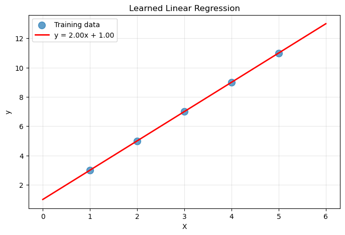

```python
plt.figure(figsize=(8, 5))
plt.scatter(X_simple, y_simple, s=100, alpha=0.7, label="Training data")
plt.plot(x_line, y_line, "r-", linewidth=2, label=model_label)

plt.xlabel("X")
plt.ylabel("y")
plt.title("Learned Linear Regression")
plt.legend()
plt.grid(True, alpha=0.3)
plt.show()
```

## Multivariate Regression

Komplexeres Beispiel mit mehreren Features

```python
np.random.seed(42)
n_samples = 100
n_features = 3
```

```python
X_multi = np.random.randn(n_samples, n_features)
```

```python
true_coef = np.array([2.5, -1.5, 3.0])
true_intercept = 5.0
```

```python
noise = np.random.randn(n_samples) * 0.25
```

```python
y_multi = X_multi @ true_coef + true_intercept + noise
```

Trainiere unser Modell

```python
multi_model = TrainableLinearRegression()
multi_model.fit(X_multi, y_multi)
```

```
<__main__.TrainableLinearRegression at 0x7eba48284450>
```

```python
print(f"Dataset: {n_samples} samples, {n_features} features")
print("True parameters:")
print(f"  True coefficients: {true_coef}")
print(f"  True intercept: {true_intercept}")
print()
print("Learned parameters:")
print(f"  Coefficients: {multi_model.coef_}")
print(f"  Intercept: {multi_model.intercept_:.3f}")
```

```
Dataset: 100 samples, 3 features
True parameters:
  True coefficients: [ 2.5 -1.5  3. ]
  True intercept: 5.0

Learned parameters:
  Coefficients: [ 2.48058418 -1.51249089  2.97310167]
  Intercept: 5.028
```

```python
print("\nCompare with true values:")
for i, (learned, true) in enumerate(zip(multi_model.coef_, true_coef)):
    error = abs(learned - true)
    print(f"Coef {i}: Learned={learned:.3f}, True={true:.3f}, Error={error:.3f}")
```

```
Compare with true values:
Coef 0: Learned=2.481, True=2.500, Error=0.019
Coef 1: Learned=-1.512, True=-1.500, Error=0.012
Coef 2: Learned=2.973, True=3.000, Error=0.027
```

## Grenzen der Normalgleichung

**Vorteile:**

- Exakte Lösung in einem Schritt
- Keine Hyperparameter
- Schnell für kleine Datensätze

**Nachteile:**

- Langsam für große Datensätze (Matrix-Inversion ist O(n³))
- Funktioniert nicht wenn X^T×X nicht invertierbar ist
- Speicherintensiv für viele Features

## Alternative: Gradient Descent

Für große Datensätze verwendet man iterative Methoden:

- Starte mit zufälligen Koeffizienten
- Verbessere schrittweise
- Folge dem Gradienten bergab
- Basis für neuronale Netze!

Visualisiere Gradient-Descent-Konzept

- Fehleroberfläche (1D zur Visualisierung)
- Schritte zum Minimum

```python
from plot_utils import plot_gradient_descent_concept
```

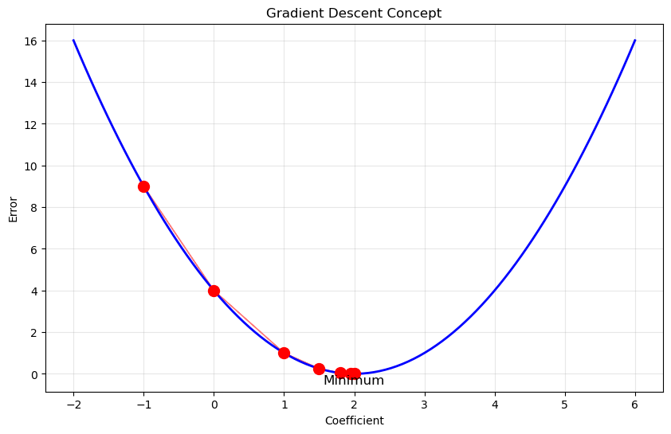

```python
plot_gradient_descent_concept()
```

## Zusammenfassung

- Modelle lernen durch Minimierung der Fehler
- Die Normalgleichung findet optimale Koeffizienten direkt
- $θ = (X^T × X)^{-1} × X^T × y$
- NumPy's `lstsq()` macht die Berechnung einfach
- Grundlage für komplexere Lernalgorithmen!

## Was haben wir gelernt?

1. **Vektoren und Matrizen** - Die Sprache des ML
2. **Skalarprodukt** - Kernoperation für Vorhersagen
3. **Matrix-Multiplikation** - Batch-Vorhersagen
4. **Modellarchitektur** - Koeffizienten + Intercept
5. **Lernen aus Daten** - Normalgleichung

**Bereit für neuronale Netze!**

## Workshop: Vollständiges Modell

Wohnungsdaten für den Workshop:

```python
from sklearn.datasets import make_regression
```

```python
X_housing, y_housing = make_regression(
    n_samples=50, n_features=4, noise=10, random_state=42
)
```

```python
feature_names = ["Size", "Bedrooms", "Location", "Age"]
```

```python
print(f"Housing dataset: {X_housing.shape[0]} houses, {X_housing.shape[1]} features")
```

```
Housing dataset: 50 houses, 4 features
```

### Aufgabe 1: Modell trainieren

Trainieren Sie ein Modell auf den Wohnungsdaten:

Trainiere Modell

```python
housing_model = TrainableLinearRegression()
housing_model.fit(X_housing, y_housing)
```

```
<__main__.TrainableLinearRegression at 0x7eba48575050>
```

```python
print("Trained Housing Model:")
print("-" * 40)
for name, coef in zip(feature_names, housing_model.coef_):
    print(f"{name:10}: {coef:+8.2f}")
print(f"{'Intercept':10}: {housing_model.intercept_:+8.2f}")
```

```
Trained Housing Model:
----------------------------------------
Size      :   +74.01
Bedrooms  :   +90.47
Location  :   +70.33
Age       :   +67.92
Intercept :    +1.45
```

### Aufgabe 2: Modellqualität bewerten

Bewerten Sie die Qualität des Modells.

Mache Vorhersagen

```python
predictions = housing_model.predict(X_housing)
```

Berechne Metriken

```python
errors = y_housing - predictions
mse = np.mean(errors**2)
mae = np.mean(np.abs(errors))
rmse = np.sqrt(mse)
```

```python
print("Model Performance:")
print(f"MSE:  {mse:.2f}")
print(f"RMSE: {rmse:.2f}")
print(f"MAE:  {mae:.2f}")
```

```
Model Performance:
MSE:  120.40
RMSE: 10.97
MAE:  8.37
```

Visualisiere Vorhersagen vs. tatsächliche Werte

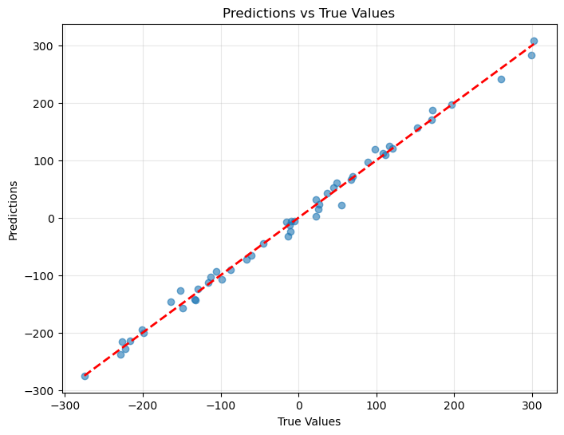

```python
plt.figure(figsize=(8, 6))
plt.scatter(y_housing, predictions, alpha=0.6)
plt.plot(
    [y_housing.min(), y_housing.max()],
    [y_housing.min(), y_housing.max()],
    "r--",
    linewidth=2,
)
plt.xlabel("True Values")
plt.ylabel("Predictions")
plt.title("Predictions vs True Values")
plt.grid(True, alpha=0.3)
plt.show()
```